—title: “MA plot and TMM normalization — step-by-step demo” author: “Mikhail Dozmorov” date: “2025-09-23” output: html_document: toc: true number_sections: true —

# Overview

This document:

- Builds a small simulated RNA-seq count matrix (mostly non-DE genes with a few large differences to mimic composition bias).
- Shows how to compute an **MA plot** (M = log fold change, A = average log abundance).
- Implements the **TMM** algorithm step-by-step for one sample vs a reference (M/A calculation, trimming by M & A, delta-method weights, weighted trimmed mean → log2 factor → linear factor).
- Computes TMM factors for all samples (manual) and compares to `edgeR::calcNormFactors()`.
- Shows MA plot before and after TMM normalization.

## Packages

```r
# Install if needed:
# if (!requireNamespace("BiocManager", quietly = TRUE)) install.packages("BiocManager")
# BiocManager::install("edgeR")

library(edgeR)
library(ggplot2)
library(gridExtra)
```

## Simulate counts (mostly non-DE; add a compositional bias)

```r
set.seed(2024)
G <- 10000   # genes
S <- 6       # samples

# baseline expression (varying gene means)
base_means <- rgamma(G, shape = 2, scale = 50)

# library size multipliers
lib_factors <- c(1.0, 0.9, 1.1, 1.2, 0.95, 1.4)
lib_sizes <- round(lib_factors * 10e6)  # raw sequencing depths

# simulate counts per-sample via NB (some overdispersion)
dispersion <- 20
counts <- matrix(0, nrow = G, ncol = S)
for (s in 1:S){
  mu <- base_means * lib_factors[s]
  counts[,s] <- rnbinom(G, mu = mu, size = dispersion)
}
colnames(counts) <- paste0("S", 1:S)
rownames(counts) <- paste0("gene", seq_len(G))

# inject composition bias: sample 6 has a small set of hugely expressed genes
set.seed(999)
hi <- sample(1:G, 100)
counts[hi, 6] <- counts[hi, 6] * 50

# quick library sizes
lib_summary <- colSums(counts)
lib_summary
```

```
##      S1      S2      S3      S4      S5      S6
## 1000237  899395 1104535 1199387  951491 2053329
```

## MA plot: definition and plotting function

- For two libraries (k and r) we compute:
  - $M_g = \log_2\!\big( (y_{gk}/N_k) / (y_{gr}/N_r) \big)$ — log fold change (sample k relative to ref r)
  - $A_g = \tfrac12\log_2\!\big( (y_{gk}/N_k)\cdot(y_{gr}/N_r) \big)$ — average log abundance
- Genes with zero counts in either library are omitted for the plot/for TMM calculation.

```r
# helper: compute log2-CPM avoiding -Inf (using edgeR::cpm with prior.count)
log2cpm_mat <- function(counts_mat, lib_sizes = colSums(counts_mat), prior.count = 0.5){
  # use edgeR cpm (returns counts-per-million)
  cpm_mat <- edgeR::cpm(counts_mat, lib.size = lib_sizes, prior.count = prior.count)
  log2(cpm_mat + 1e-6)  # tiny offset for numerical safety (visualization)
}

# helper: make MA data (M, A) for two columns k and r
make_MA <- function(counts, k, r, lib_sizes = colSums(counts), prior.count = 0.5){
  yk <- counts[, k]; yr <- counts[, r]
  Nk <- lib_sizes[k]; Nr <- lib_sizes[r]
  # remove genes with zero in either (TMM trims these anyway)
  valid <- (yk > 0) & (yr > 0)
  yk_v <- yk[valid]; yr_v <- yr[valid]
  M <- log2( (yk_v / Nk) / (yr_v / Nr) )
  A <- 0.5 * log2( (yk_v / Nk) * (yr_v / Nr) )
  data.frame(gene = rownames(counts)[valid], M = M, A = A, yk = yk_v, yr = yr_v)
}

# plotting function
plot_MA <- function(ma_df, title = "MA plot", highlight = NULL){
  p <- ggplot(ma_df, aes(x = A, y = M)) +
    geom_hex(bins = 80) +
    geom_hline(yintercept = 0, linetype = "dashed", color = "red") +
    labs(title = title, x = "A = 0.5 * log2( (p_k)*(p_r) )", y = "M = log2( p_k / p_r )") +
    theme_minimal()
  if (!is.null(highlight)) {
    p <- p + geom_point(data = ma_df[rownames(ma_df) %in% highlight, , drop = FALSE],
                        aes(x = A, y = M), color = "orange", size = 1)
  }
  p
}
```

## Example MA plot (sample 6 vs chosen reference)

Pick a reference sample. edgeR chooses the sample whose upper quartile CPM is closest to the mean upper quartile; we replicate that to pick the ref.

```r
# choose reference as edgeR would (upper-quartile closeness)
uq <- apply(edgeR::cpm(counts, prior.count = 0.5), 2, function(x) quantile(x, 0.75))
ref <- which.min(abs(uq - mean(uq)))
ref
```

```
## S3
##  3
```

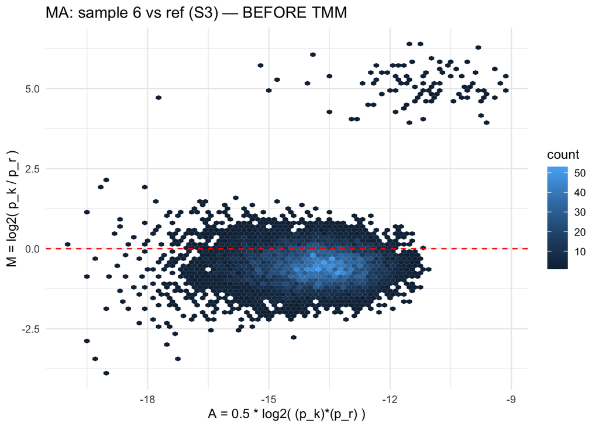

```r
# plot MA: sample 6 vs reference
ma_6_vs_ref <- make_MA(counts, k = 6, r = ref)
p_ma_before <- plot_MA(ma_6_vs_ref, title = paste0("MA: sample 6 vs ref (S", ref, ") — BEFORE TMM"))
p_ma_before
```

*Interpretation:* See a global shift away from $M=0$ if composition bias exists (we injected such bias into sample 6).

## TMM: manual implementation for one sample vs reference

Steps implemented below (mirrors the algorithm in Robinson & Oshlack, 2010):

1. Compute $M_g$ and $A_g$ for genes with positive counts in both libraries.
2. Trim genes with extreme $M$ (default 30% at each tail) and extreme $A$ (default 5% at each tail). The *double trim* keeps genes that survive both trims.
3. Compute approximate variance of $M_g$ by delta method (for a binomial proportion):

   $$\operatorname{Var}(M_g) \approx \left(\frac{1}{y_{gk}} -
   \frac{1}{N_k}\right) + \left(\frac{1}{y_{gr}} - \frac{1}{N_r}\right).$$

   Then weights = inverse variance.
4. Weighted mean of kept $M_g$ gives the *log2* normalization factor for sample $k$ vs reference $r$: $\widehat{\log_2 f_k} = \dfrac{\sum_{g\in G^*} w_g M_g}{\sum_{g\in G^*} w_g}$. Then $f_k = 2^{\widehat{\log_2 f_k}}$.

```r
# parameters
trim.M <- 0.30  # 30% trimming for M
trim.A <- 0.05  # 5% trimming for A

# function to compute manual TMM factor for sample k relative to ref r
calc_TMM_manual <- function(counts, k, r, lib_sizes = colSums(counts),
                            trim.M = 0.30, trim.A = 0.05){
  yk <- counts[,k]; yr <- counts[,r]
  Nk <- lib_sizes[k]; Nr <- lib_sizes[r]
  valid <- (yk > 0) & (yr > 0)
  yk_v <- yk[valid]; yr_v <- yr[valid]
  M <- log2( (yk_v / Nk) / (yr_v / Nr) )
  A <- 0.5 * log2( (yk_v / Nk) * (yr_v / Nr) )
  # compute delta-method approximate variance of M
  varM <- (1 / yk_v - 1 / Nk) + (1 / yr_v - 1 / Nr)
  wg <- 1 / varM
  # trimming
  m_low <- quantile(M, probs = trim.M); m_high <- quantile(M, probs = 1 - trim.M)
  a_low <- quantile(A, probs = trim.A); a_high <- quantile(A, probs = 1 - trim.A)
  keep <- (M > m_low) & (M < m_high) & (A > a_low) & (A < a_high) & is.finite(wg)
  # weighted mean of M over kept genes
  w <- wg[keep]
  wm <- if (sum(w) > 0) sum( w * M[keep] ) / sum(w) else NA_real_
  # log2 factor -> linear factor
  list(log2_factor = wm, factor = 2^wm, keep_indices = which(valid)[keep],
       M = M, A = A, wg = wg)
}

# compute for sample 6 relative to chosen ref
tmm6 <- calc_TMM_manual(counts, k = 6, r = ref, lib_sizes = colSums(counts),
                        trim.M = trim.M, trim.A = trim.A)
tmm6$log2_factor
```

```
## [1] -0.5393223
```

```r
tmm6$factor
```

```
## [1] 0.688094
```

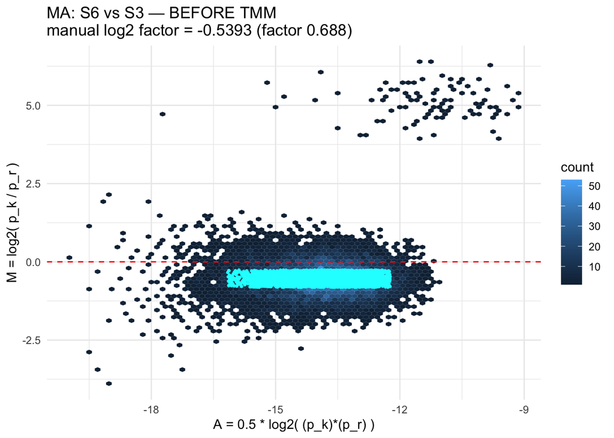

```r
# highlight trimmed genes on MA plot (showing kept genes)
kept_genes <- rownames(counts)[tmm6$keep_indices]
p_ma_before + geom_point(data = subset(ma_6_vs_ref, gene %in% kept_genes),
                         aes(x = A, y = M), color = "cyan", size = 0.6) +
  ggtitle(sprintf("MA: S6 vs S%d — BEFORE TMM\nmanual log2 factor = %.4f (factor %.3f)",
                  ref, tmm6$log2_factor, tmm6$factor))
```

## Compute TMM factors for all samples (manual) and compare to edgeR

- We will compute a manual TMM factor for every sample relative to the same reference `ref` and then scale the manual factors to have geometric mean = 1 so they are comparable to `edgeR` output.
- Then call `edgeR::calcNormFactors()` and compare.

```r
# manual factors for all samples relative to ref
manual_log2 <- numeric(S)
manual_fac <- numeric(S)
keep_list <- vector("list", S)
for (k in 1:S){
  if (k == ref){
    manual_log2[k] <- 0
    manual_fac[k] <- 1
    keep_list[[k]] <- integer(0)
  } else {
    res <- calc_TMM_manual(counts, k = k, r = ref, lib_sizes = colSums(counts),
                           trim.M = trim.M, trim.A = trim.A)
    manual_log2[k] <- res$log2_factor
    manual_fac[k] <- res$factor
    keep_list[[k]] <- rownames(counts)[res$keep_indices]
  }
}

# scale manual factors so that geometric mean = 1 (edgeR reports factors with geo mean ~1)
gm <- exp(mean(log(manual_fac)))
manual_norm_factors <- manual_fac / gm

# edgeR calcNormFactors (specify refColumn to match our chosen ref if desired)
dge <- DGEList(counts = counts)
dge$samples$lib.size <- colSums(counts)
# specify refColumn so edgeR computes factors relative to that ref (for close comparability)
edgef <- calcNormFactors(dge, method = "TMM", refColumn = ref)
edge_factors <- edgef$samples$norm.factors

# report
data.frame(sample = colnames(counts),
           lib.size = colSums(counts),
           manual_factor = manual_norm_factors,
           edgeR_factor = edge_factors)
```

```
##    sample lib.size manual_factor edgeR_factor
## S1     S1  1000237      1.064607    1.0644877
## S2     S2   899395      1.064210    1.0642979
## S3     S3  1104535      1.064482    1.0645199
## S4     S4  1199387      1.063999    1.0639378
## S5     S5   951491      1.063941    1.0639617
## S6     S6  2053329      0.732464    0.7324873
```

*Interpretation:* The `manual_factor` and `edgeR_factor` are very close. Small differences can arise due to tie handling and small numeric details.

## MA plot AFTER applying TMM normalization

To visualize the effect of normalization on MA, we compute CPM using **effective library sizes**: `effective_libsize = lib.size * norm.factor`. We’ll use `edgeR`’s normalized factors for this visualization.

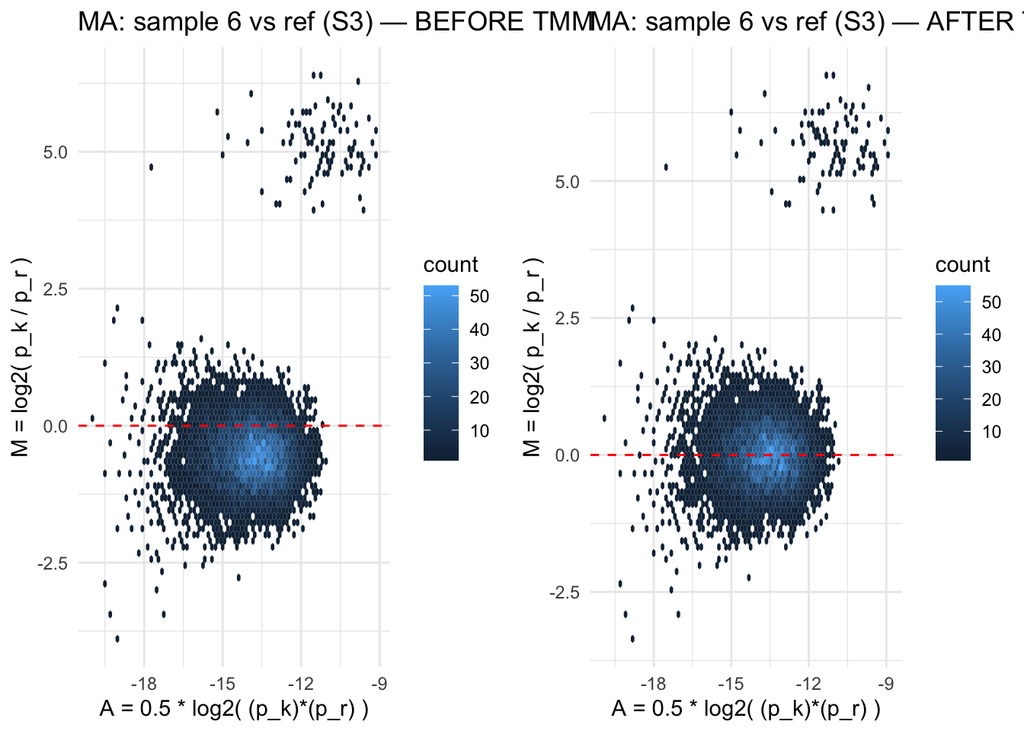

```r
# effective library sizes using edgeR's factors
eff_libsizes_edgeR <- colSums(counts) * edge_factors

# MA between sample 6 and ref after applying TMM (via effective lib sizes)
ma_after <- make_MA(counts, k = 6, r = ref, lib_sizes = eff_libsizes_edgeR)
p_ma_after <- plot_MA(ma_after, title = paste0("MA: sample 6 vs ref (S", ref, ") — AFTER TMM (edgeR factors)"))
grid.arrange(p_ma_before, p_ma_after, ncol = 2)
```

*Interpretation:* After TMM normalization, the bulk of M values should be centered near zero (dashed red line), demonstrating removal of the global composition bias.

## Quick check: normalized log-CPM boxplots (before/after)

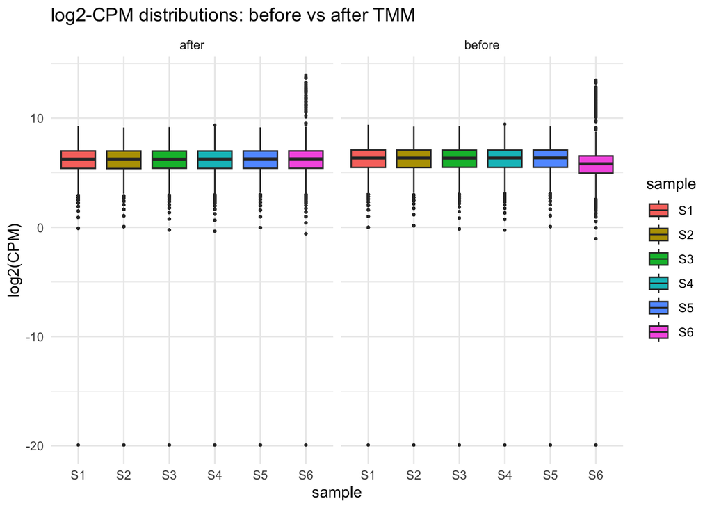

```r
log2cpm_before <- log2(edgeR::cpm(counts, lib.size = colSums(counts), prior.count = 0.5) + 1e-6)
log2cpm_after  <- log2(edgeR::cpm(counts, lib.size = eff_libsizes_edgeR, prior.count = 0.5) + 1e-6)

df_before <- data.frame(value = as.vector(log2cpm_before), sample = rep(colnames(counts), each = nrow(counts)), stage = "before")
df_after  <- data.frame(value = as.vector(log2cpm_after),  sample = rep(colnames(counts), each = nrow(counts)), stage = "after")
df_both <- rbind(df_before, df_after)

ggplot(df_both, aes(x = sample, y = value, fill = sample)) +
  geom_boxplot(outlier.size = 0.4) +
  facet_wrap(~stage) +
  theme_minimal() +
  labs(title = "log2-CPM distributions: before vs after TMM", y = "log2(CPM)")
```

## Notes & caveats

- **What TMM assumes:** Most genes are not differentially expressed (or that the majority of genes are balanced between conditions).
- **Trim settings:** The defaults (trim M by 30% and A by 5%) are usually robust; they remove extreme log-fold-changes and extreme intensities that would otherwise bias the scaling factor.
- **Weights:** We used the delta-method approximate variance for log ratios and applied inverse-variance weighting — this matches the approach in Robinson & Oshlack (2010) and the implementation in `edgeR`.
- **edgeR:** Use `calcNormFactors()` in practice. Manual implementation is useful for teaching and validation.
- **Effect on downstream DE:** The normalization changes effective library sizes and therefore the offsets in GLM-based differential testing (or the CPMs used in t/voom workflows).